# Report of Course Project

This is the report of Course Project in Pratical Machine Learning.

## Backgroud

Using devices such as Jawbone Up, Nike FuelBand, and Fitbit it is now possible to collect a large amount of data about personal activity relatively inexpensively. These types of devices are part of the quantified self movement – a group of enthusiasts who take measurements about themselves regularly to improve their health, to find patterns in their behavior, or because they are tech geeks.

With the data collected from accelerometers on the belt, forearm, arm, and dumbell of 6 participants. They were asked to perform barbell lifts correctly and incorrectly in 5 different ways. Our purpose is to predict their manner in which they did in their exericse.

## Data

The data can be downloaded from

training data: https://d396qusza40orc.cloudfront.net/predmachlearn/pml-training.csv

testing data: https://d396qusza40orc.cloudfront.net/predmachlearn/pml-testing.csv

Before we load the data into R, we can have a preview in excel. Many variables in these two files are nulls or NA. We believe that these variables should be removed from the predicotors.

The blank and NA should be interpreted as NA values when we load the data into R. The code can be shown like below

```r
Data<-read.csv("pml-training.csv",na.strings=c("NA",""));
Prediction<-read.csv("pml-testing.csv",na.strings=c("NA",""));
dim(Data); dim(Prediction)
```

```
## [1] 19622   160
```

```
## [1]  20 160
```

## Data Cleaning

We can not analysis the data before we remove these NA variables. Also, there will be some unrelevant variables, which should also be removed in our analysis.

- Remove these NA and unrelevant variables.

```r
CleaningData<-subset(Data[,colSums(is.na(Data))==0],select=-c(1:7))
Pre<-subset(Prediction[,colSums(is.na(Data))==0],select=-c(1:7))
dim(CleaningData); dim(Pre)
```

```
## [1] 19622    53
```

```
## [1] 20 53
```

- Check the variables that have extremely low variance

```r
library(caret)
zeroVar<-nearZeroVar(CleaningData[sapply(CleaningData,is.numeric)],saveMetrics=TRUE)
pml<-CleaningData[,zeroVar$nzv==0];
dim(pml)
```

```
## [1] 19622    53
```

Now, we successfully reduced the data dimension from 160 to 53.

## Split data to training and testing for cross validation.

```r
set.seed(1)
inTrain<-createDataPartition(y=pml$classe,p=0.7,list=FALSE);
training<-pml[inTrain,];testing<-pml[-inTrain,];
dim(training);dim(testing)
```

```
## [1] 13737    53
```

```
## [1] 5885   53
```

We got 13737 samples and 52 variables for training, 5885 samples and 52 variables for testing. (The left one variable is the object “classe”)

## Analysis

Noticed that the classe variable is a factor variable. We mainly used the “rpart” and “random forest” to predict the manner.

- Rpart

```r
set.seed(1)
modelRpart<-train(training$classe~.,method="rpart",data=training);
modelRpart
```

```
## CART
##
## 13737 samples
##    52 predictor
##     5 classes: 'A', 'B', 'C', 'D', 'E'
##
## No pre-processing
## Resampling: Bootstrapped (25 reps)
##
## Summary of sample sizes: 13737, 13737, 13737, 13737, 13737, 13737, ...
##
## Resampling results across tuning parameters:
##
##   cp          Accuracy   Kappa       Accuracy SD  Kappa SD
##   0.03661886  0.5122517  0.36472682  0.02059009   0.03097362
##   0.05947174  0.4293446  0.23010053  0.06390366   0.10801776
##   0.11789238  0.3273967  0.06518168  0.04349453   0.06396846
##
## Accuracy was used to select the optimal model using  the largest value.
## The final value used for the model was cp = 0.03661886.
```

```r
confusionMatrix(testing$classe,predict(modelRpart,newdata=testing));
```

```
## Confusion Matrix and Statistics
##
##           Reference
## Prediction    A    B    C    D    E
##          A 1510   27  132    0    5
##          B  463  389  287    0    0
##          C  462   36  528    0    0
##          D  427  163  374    0    0
##          E  179  141  299    0  463
##
## Overall Statistics
##
##                Accuracy : 0.4911
##                  95% CI : (0.4782, 0.5039)
##     No Information Rate : 0.5167
##     P-Value [Acc > NIR] : 1
##
##                   Kappa : 0.3352
##  Mcnemar's Test P-Value : NA
##
## Statistics by Class:
##
##                      Class: A Class: B Class: C Class: D Class: E
## Sensitivity            0.4965   0.5146  0.32593       NA  0.98932
## Specificity            0.9423   0.8538  0.88324   0.8362  0.88573
## Pos Pred Value         0.9020   0.3415  0.51462       NA  0.42791
## Neg Pred Value         0.6364   0.9227  0.77526       NA  0.99896
## Prevalence             0.5167   0.1285  0.27528   0.0000  0.07952
## Detection Rate         0.2566   0.0661  0.08972   0.0000  0.07867
## Detection Prevalence   0.2845   0.1935  0.17434   0.1638  0.18386
## Balanced Accuracy      0.7194   0.6842  0.60458       NA  0.93752
```

This method has a very low accuracy in predicting manner.

- Random Forest

This method use trees as building blocks to build more complex models. We use randomForest function directly which is much faster than train function.

```r
library(randomForest)
set.seed(1)
modelRF<-randomForest(classe~.,data=training,importance=TRUE);
modelRF
```

```
##
## Call:
##  randomForest(formula = classe ~ ., data = training, importance = TRUE)
##                Type of random forest: classification
##                      Number of trees: 500
## No. of variables tried at each split: 7
##
##         OOB estimate of  error rate: 0.48%
## Confusion matrix:
##      A    B    C    D    E class.error
## A 3901    5    0    0    0 0.001280082
## B   11 2642    5    0    0 0.006019564
## C    0   13 2380    3    0 0.006677796
## D    0    0   21 2229    2 0.010213144
## E    0    0    2    4 2519 0.002376238
```

```r
confusionMatrix(testing$classe,predict(modelRF,newdata=testing));
```

```
## Confusion Matrix and Statistics
##
##           Reference
## Prediction    A    B    C    D    E
##          A 1673    0    0    0    1
##          B    1 1136    2    0    0
##          C    0    7 1018    1    0
##          D    0    0    5  958    1
##          E    0    0    0    1 1081
##
## Overall Statistics
##
##                Accuracy : 0.9968
##                  95% CI : (0.995, 0.9981)
##     No Information Rate : 0.2845
##     P-Value [Acc > NIR] : < 2.2e-16
##
##                   Kappa : 0.9959
##  Mcnemar's Test P-Value : NA
##
## Statistics by Class:
##
##                      Class: A Class: B Class: C Class: D Class: E
## Sensitivity            0.9994   0.9939   0.9932   0.9979   0.9982
## Specificity            0.9998   0.9994   0.9984   0.9988   0.9998
## Pos Pred Value         0.9994   0.9974   0.9922   0.9938   0.9991
## Neg Pred Value         0.9998   0.9985   0.9986   0.9996   0.9996
## Prevalence             0.2845   0.1942   0.1742   0.1631   0.1840
## Detection Rate         0.2843   0.1930   0.1730   0.1628   0.1837
## Detection Prevalence   0.2845   0.1935   0.1743   0.1638   0.1839
## Balanced Accuracy      0.9996   0.9966   0.9958   0.9983   0.9990
```

The accuracy in testing data is very closed to 100%.

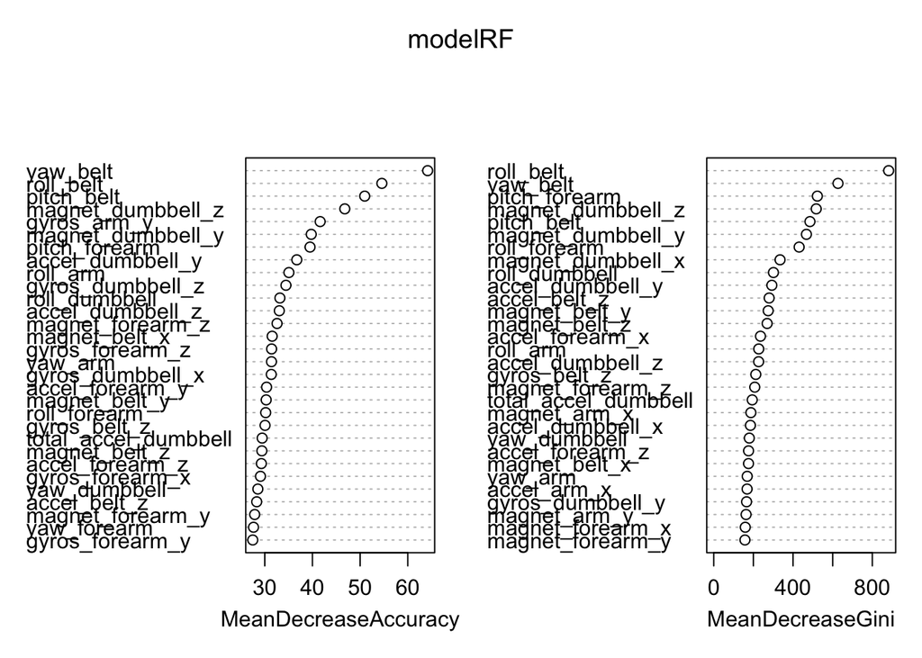

```r
varImpPlot(modelRF)
```

we can see which variables have higher impact on the prediction.

With this two methods, we can know that the accuracy of random forest method is higher.

## Conclusion

Now, with the results showed before, we know that the random forest model did a good job. So we can predict the manner in testing data with random forest method.

```r
Prediction<-predict(modelRF,newdata=Pre)
Prediction
```

```
##  1  2  3  4  5  6  7  8  9 10 11 12 13 14 15 16 17 18 19 20
##  B  A  B  A  A  E  D  B  A  A  B  C  B  A  E  E  A  B  B  B
## Levels: A B C D E
```